# I. Preprocessing

```python
pip install squarify
```

```python
import pandas as pd
import numpy as np
import seaborn as sns
import matplotlib.pyplot as plt
import scipy as sp
from sklearn.preprocessing import scale
from sklearn.model_selection import train_test_split, GridSearchCV, cross_val_score
import statsmodels.formula.api as smf

from warnings import filterwarnings
filterwarnings('ignore')
from scipy import stats
import squarify as sq
color = sns.color_palette()
```

```python
df = pd.read_csv('top50.csv', encoding = "ISO-8859-1")
```

Data source: https://www.kaggle.com/leonardopena/top50spotify2019

The top 50 most listened songs in the world by spotify. This dataset has several variables about the songs.

The data includes: 50 songs and 13 variables

Varaibale definition:

1. Danceability: Describes how suitable a track is for dancing based on a combination of musical elements including tempo, rhythm stability, beat strength, and overall regularity.
1. Valence: Describes the musical positiveness conveyed by a track. Tracks with high valence sound more positive (e.g. happy, cheerful, euphoric), while tracks with low valence sound more negative (e.g. sad, depressed, angry).
2. Energy: Represents a perceptual measure of intensity and activity. Typically, energetic tracks feel fast, loud, and noisy. For example, death metal has high energy, while a Bach prelude scores low on the scale.
3. Beats per minute (BPM): the speed or pace of a given piece, and derives directly from the average beat duration.
4. Loudness: The overall loudness of a track in decibels (dB). Loudness values are averaged across the entire track and are useful for comparing relative loudness of tracks.
5. Speechiness: This detects the presence of spoken words in a track. The more exclusively speech-like the recording (e.g. talk show, audio book, poetry), the closer to 1.0 the attribute value.
6. Liveness: Detects the presence of an audience in the recording. Higher liveness values represent an increased probability that the track was performed live.
7. Acousticness: A confidence measure from 0.0 to 1.0 of whether the track is acoustic.

```python
df.head()
```

|  | Unnamed: 0 | Track.Name | Artist.Name | Genre | Beats.Per.Minute | Energy | Danceability | Loudness..dB.. | Liveness | Valence. | Length. | Acousticness.. | Speechiness. | Popularity |
| --- | --- | --- | --- | --- | --- | --- | --- | --- | --- | --- | --- | --- | --- | --- |
| 0 | 1 | Señorita | Shawn Mendes | canadian pop | 117 | 55 | 76 | -6 | 8 | 75 | 191 | 4 | 3 | 79 |
| 1 | 2 | China | Anuel AA | reggaeton flow | 105 | 81 | 79 | -4 | 8 | 61 | 302 | 8 | 9 | 92 |
| 2 | 3 | boyfriend (with Social House) | Ariana Grande | dance pop | 190 | 80 | 40 | -4 | 16 | 70 | 186 | 12 | 46 | 85 |
| 3 | 4 | Beautiful People (feat. Khalid) | Ed Sheeran | pop | 93 | 65 | 64 | -8 | 8 | 55 | 198 | 12 | 19 | 86 |
| 4 | 5 | Goodbyes (Feat. Young Thug) | Post Malone | dfw rap | 150 | 65 | 58 | -4 | 11 | 18 | 175 | 45 | 7 | 94 |

```python
df.info()
```

```
<class 'pandas.core.frame.DataFrame'>
RangeIndex: 50 entries, 0 to 49
Data columns (total 14 columns):
Unnamed: 0          50 non-null int64
Track.Name          50 non-null object
Artist.Name         50 non-null object
Genre               50 non-null object
Beats.Per.Minute    50 non-null int64
Energy              50 non-null int64
Danceability        50 non-null int64
Loudness..dB..      50 non-null int64
Liveness            50 non-null int64
Valence.            50 non-null int64
Length.             50 non-null int64
Acousticness..      50 non-null int64
Speechiness.        50 non-null int64
Popularity          50 non-null int64
dtypes: int64(11), object(3)
memory usage: 5.6+ KB
```

```python
df.isnull().sum()
```

```
Unnamed: 0          0
Track.Name          0
Artist.Name         0
Genre               0
Beats.Per.Minute    0
Energy              0
Danceability        0
Loudness..dB..      0
Liveness            0
Valence.            0
Length.             0
Acousticness..      0
Speechiness.        0
Popularity          0
dtype: int64
```

# 2. Exploration Data Analysis

```python
df.describe()
```

|  | Unnamed: 0 | Beats.Per.Minute | Energy | Danceability | Loudness..dB.. | Liveness | Valence. | Length. | Acousticness.. | Speechiness. | Popularity |
| --- | --- | --- | --- | --- | --- | --- | --- | --- | --- | --- | --- |
| count | 50.00000 | 50.000000 | 50.000000 | 50.00000 | 50.000000 | 50.000000 | 50.000000 | 50.000000 | 50.000000 | 50.000000 | 50.000000 |
| mean | 25.50000 | 120.060000 | 64.060000 | 71.38000 | -5.660000 | 14.660000 | 54.600000 | 200.960000 | 22.160000 | 12.480000 | 87.500000 |
| std | 14.57738 | 30.898392 | 14.231913 | 11.92988 | 2.056448 | 11.118306 | 22.336024 | 39.143879 | 18.995553 | 11.161596 | 4.491489 |
| min | 1.00000 | 85.000000 | 32.000000 | 29.00000 | -11.000000 | 5.000000 | 10.000000 | 115.000000 | 1.000000 | 3.000000 | 70.000000 |
| 25% | 13.25000 | 96.000000 | 55.250000 | 67.00000 | -6.750000 | 8.000000 | 38.250000 | 176.750000 | 8.250000 | 5.000000 | 86.000000 |
| 50% | 25.50000 | 104.500000 | 66.500000 | 73.50000 | -6.000000 | 11.000000 | 55.500000 | 198.000000 | 15.000000 | 7.000000 | 88.000000 |
| 75% | 37.75000 | 137.500000 | 74.750000 | 79.75000 | -4.000000 | 15.750000 | 69.500000 | 217.500000 | 33.750000 | 15.000000 | 90.750000 |
| max | 50.00000 | 190.000000 | 88.000000 | 90.00000 | -2.000000 | 58.000000 | 95.000000 | 309.000000 | 75.000000 | 46.000000 | 95.000000 |

```python
df['Artist.Name'].value_counts()
```

```
Ed Sheeran          4
The Chainsmokers    2
Marshmello          2
Post Malone         2
Ariana Grande       2
Billie Eilish       2
J Balvin            2
Sech                2
Lil Nas X           2
Shawn Mendes        2
Lizzo               1
Kygo                1
Lady Gaga           1
Lauv                1
MEDUZA              1
Jhay Cortez         1
Ali Gatie           1
Bad Bunny           1
Nicky Jam           1
ROSALÍA             1
Jonas Brothers      1
Khalid              1
Drake               1
Chris Brown         1
Tones and I         1
Maluma              1
Daddy Yankee        1
Anuel AA            1
Taylor Swift        1
Martin Garrix       1
Lewis Capaldi       1
DJ Snake            1
Lunay               1
Young Thug          1
Y2K                 1
Katy Perry          1
Sam Smith           1
Lil Tecca           1
Name: Artist.Name, dtype: int64
```

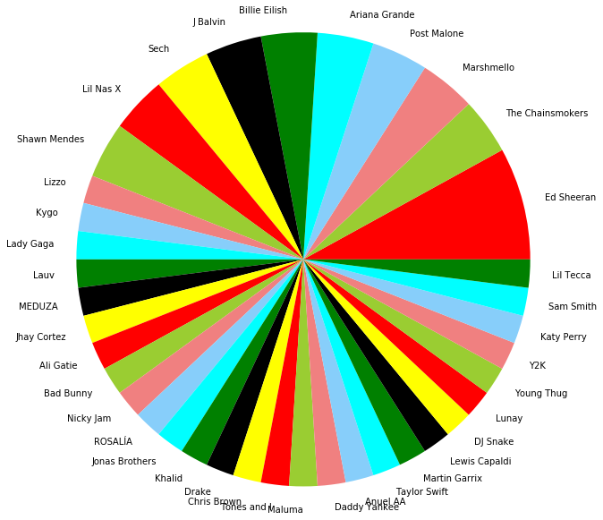

```python
#Pie charts
labels = df['Artist.Name'].value_counts().index
sizes = df['Artist.Name'].value_counts().values
colors = ['red', 'yellowgreen', 'lightcoral', 'lightskyblue','cyan', 'green', 'black','yellow']
plt.figure(figsize = (10,10))
plt.pie(sizes, labels=labels, colors=colors)
autopct=('%1.1f%%')
plt.axis('equal')
plt.show()
```

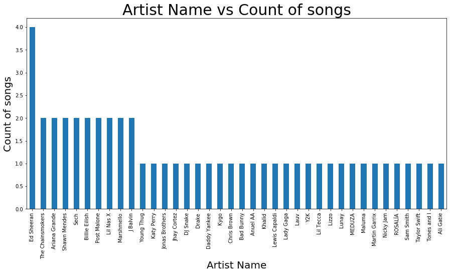

```python
fig = plt.figure(figsize = (15,7))
df.groupby('Artist.Name')['Track.Name'].agg(len).sort_values(ascending = False).plot(kind = 'bar')
plt.xlabel('Artist Name', fontsize = 20)
plt.ylabel('Count of songs', fontsize = 20)
plt.title('Artist Name vs Count of songs', fontsize = 30)
```

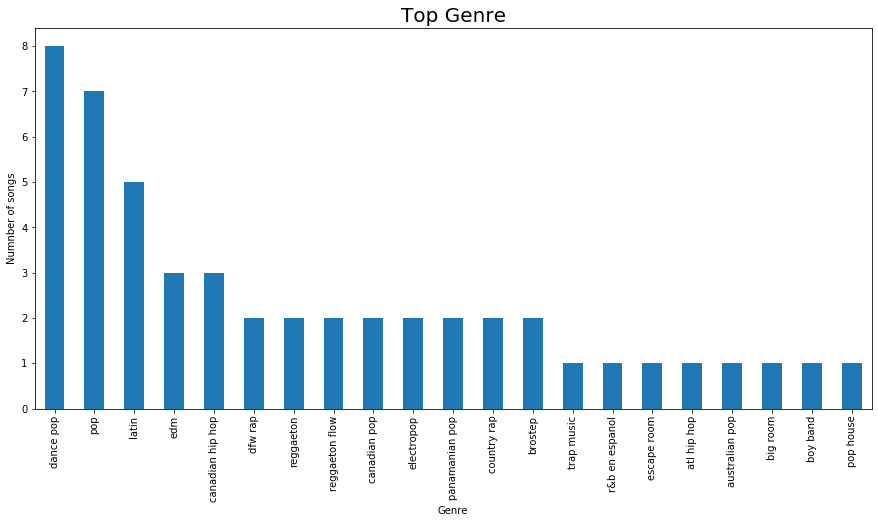

```python
fig = plt.figure(figsize = (15,7))
df['Genre'].value_counts().sort_values(ascending=False).plot(kind = 'bar')
plt.ylabel('Numnber of songs')
plt.title('Top Genre', size=20)
plt.xlabel('Genre')
plt.plot();
```

Dance pop, ppo and latin are the most favorite genre in top 50 Spotify 2019.

[figure not shown]

```python
plt.figure(figsize=(14,8))
sq.plot(sizes=df.Genre.value_counts(), label=df["Genre"].unique(), alpha=.8 )
plt.axis('off')
plt.show()
```

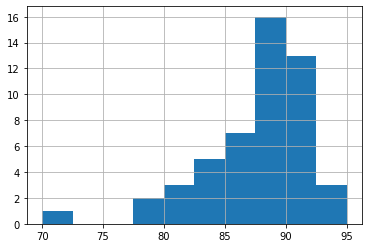

```python
df['Popularity'].hist()
```

In general, most of the songs in top 50 has the populartity from 87 to 90

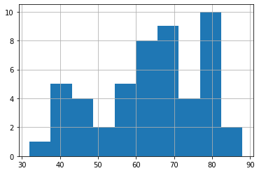

```python
df['Energy'].hist()
```

The distribution of energy focus on three branches: around 40, from 60 to 70 and around 80

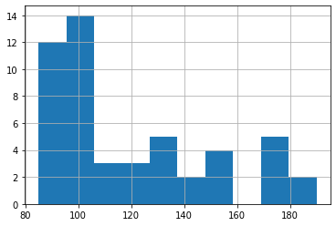

```python
df['Beats.Per.Minute'].hist()
```

In general, most of the songs in top 50 has the Beats per Minutes from range 85 to 115.

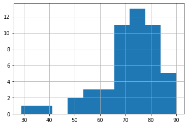

```python
df['Danceability'].hist()
```

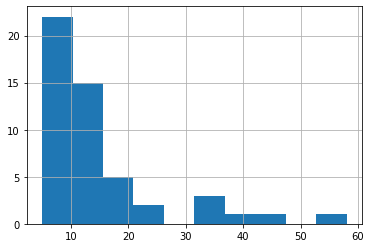

```python
df['Liveness'].hist()
```

In general, most of the songs in top 50 has the Liveness at around 5.

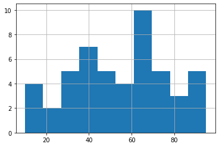

```python
df['Valence.'].hist()
```

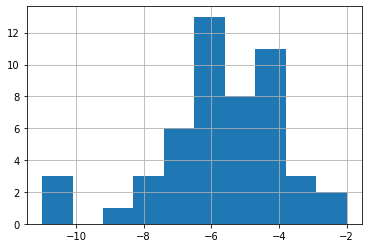

```python
df['Loudness..dB..'].hist()
```

In general, the distribution of Loudness is mainly around -6 and -4.

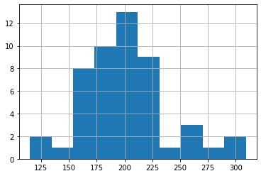

```python
df['Length.'].hist()
```

Most of the songs has the length at around 200 seconds. The ditribution of the lenght is mainly from 175 to 225 seconds.

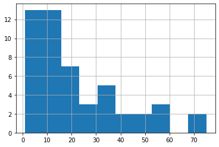

```python
df['Acousticness..'].hist()
```

Most of the songs have the acousticness from 0 10 15.

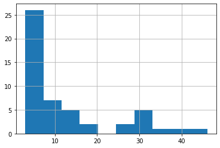

```python
df['Speechiness.'].hist()
```

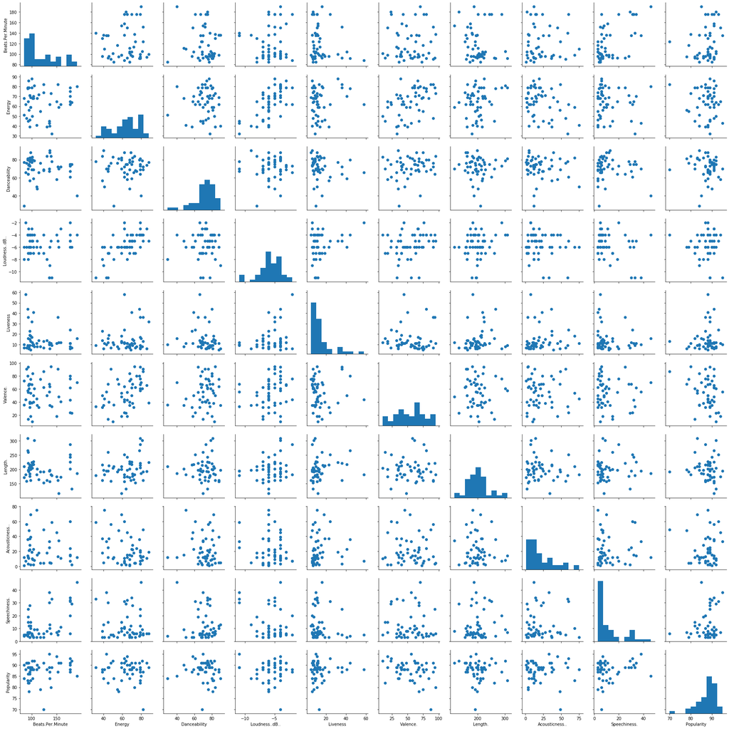

```python
matrix = ['Beats.Per.Minute', 'Energy', 'Danceability', 'Loudness..dB..', 'Liveness', 'Valence.', 'Length.', 'Acousticness..', 'Speechiness.', 'Popularity']
g = sns.PairGrid(data = df, vars = matrix);
g = g.map_offdiag(plt.scatter);
g.map_diag(plt.hist);
```

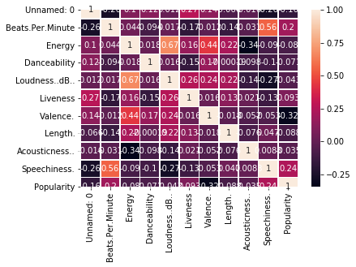

```python
corrMatrix = df.corr()
sns.heatmap(corrMatrix, annot=True, linewidths=.5);
fig = plt.figure(figsize = (16,7))
```

```python
df.corr()
```

|  | Unnamed: 0 | Beats.Per.Minute | Energy | Danceability | Loudness..dB.. | Liveness | Valence. | Length. | Acousticness.. | Speechiness. | Popularity |
| --- | --- | --- | --- | --- | --- | --- | --- | --- | --- | --- | --- |
| Unnamed: 0 | 1.000000 | -0.259193 | 0.102649 | 0.122691 | 0.011914 | 0.270659 | 0.137329 | -0.065844 | -0.015993 | -0.257506 | -0.160680 |
| Beats.Per.Minute | -0.259193 | 1.000000 | 0.043756 | -0.094183 | 0.017016 | -0.167286 | -0.011586 | -0.139288 | -0.031450 | 0.557052 | 0.196097 |
| Energy | 0.102649 | 0.043756 | 1.000000 | 0.018254 | 0.670794 | 0.162768 | 0.438820 | 0.224677 | -0.339892 | -0.089860 | -0.080295 |
| Danceability | 0.122691 | -0.094183 | 0.018254 | 1.000000 | 0.016255 | -0.149636 | 0.172829 | -0.000185 | -0.098165 | -0.103472 | -0.071413 |
| Loudness..dB.. | 0.011914 | 0.017016 | 0.670794 | 0.016255 | 1.000000 | 0.258652 | 0.237614 | 0.219219 | -0.138300 | -0.272213 | -0.043085 |
| Liveness | 0.270659 | -0.167286 | 0.162768 | -0.149636 | 0.258652 | 1.000000 | 0.016123 | 0.131782 | 0.021328 | -0.125286 | 0.092564 |
| Valence. | 0.137329 | -0.011586 | 0.438820 | 0.172829 | 0.237614 | 0.016123 | 1.000000 | -0.017782 | -0.052323 | -0.053242 | -0.317752 |
| Length. | -0.065844 | -0.139288 | 0.224677 | -0.000185 | 0.219219 | 0.131782 | -0.017782 | 1.000000 | -0.076293 | 0.046755 | -0.087639 |
| Acousticness.. | -0.015993 | -0.031450 | -0.339892 | -0.098165 | -0.138300 | 0.021328 | -0.052323 | -0.076293 | 1.000000 | 0.008293 | -0.034684 |
| Speechiness. | -0.257506 | 0.557052 | -0.089860 | -0.103472 | -0.272213 | -0.125286 | -0.053242 | 0.046755 | 0.008293 | 1.000000 | 0.238553 |
| Popularity | -0.160680 | 0.196097 | -0.080295 | -0.071413 | -0.043085 | 0.092564 | -0.317752 | -0.087639 | -0.034684 | 0.238553 | 1.000000 |

Bivariate Exploration